# AdaBoost Tutorial

Souad Guemghar

03 March 2021

## Random Forests vs AdaBoost

These are notes from the StatQuest video presentation https://www.youtube.com/watch?v=LsK-xG1cLYA&t=0s

AdaBoost is based on three concepts:

| Random Forests | AdaBoost |
| --- | --- |
| Each tree is a full tree, some may be bigger than others but there is no predetermined maximum tree depth. | Trees are usually a node and two leaves: a **stump**. Stumps only use one variable to make predictions. Stumps are **weak learners**. |
| Each tree has an equal vote on the final classification. | Some stumps have more say on the final classification than others. |
| Each decision tree is made independently of the others, order is irrelevant. | Order matters, each stump is made by taking the previous stump’s mistakes (error) into account. |

## Creating a forest of stumps with AdaBoost

1. Give each sample (row) a weight that indicates how important it is to be correctly classified. Start with the same weight for all rows $\frac{1}{N}$.
2. To select the root node of the first stump, we calculate the Gini index for each feature, and select the feature with the lowest index which now makes the first stump in the forest.
3. Calculate the **Total Error** for the stump, which is the sum of the weights associated with the incorrectly classified samples. Total Error will always be between **0** (perfect stump) and **1** (horrible stump).
4. Determine the **Amount of Say** of the stump with the formula:
   $$\text{Amount of Say} = \frac{1}{2} \log (\frac{1 - \text{Total Error}}{\text{Total Error}})$$
   Note that the lower the error, the higher the Amount of Say and vice versa. If Total Error is **0.5**, then the Amount of Say is **0**.

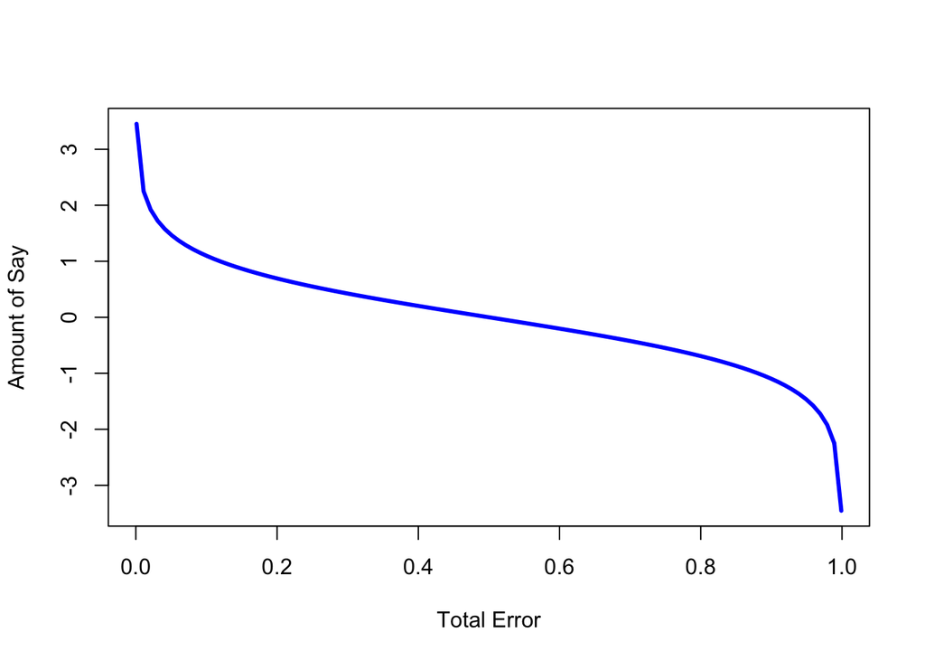

5. **Increase** the sample weight of the incorrectly classified samples using the formula:
   $$\text{New Sample Weight} = \text{sample weight} \times e^{\text{amount of say}}$$
   **Note**: this is equivalent to scaling the sample weight by $\sqrt{\frac{1 - \text{Total Error}}{\text{Total Error}}}$.

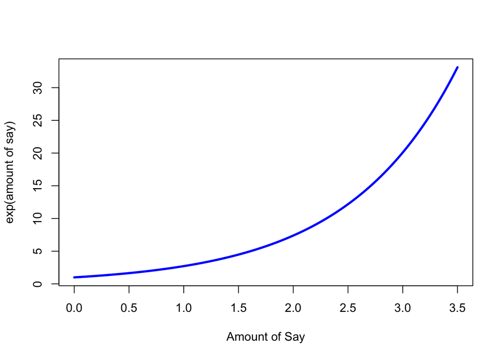

6. **Decrease** the sample weights of the correctly classified samples using the formula:
   $$\text{New Sample Weight} = \text{sample weight} \times e^{-\text{amount of say}}$$
   **Note**: this is equivalent to scaling the sample weight by $\sqrt{\frac{\text{Total Error}}{1 - \text{Total Error}}}$.

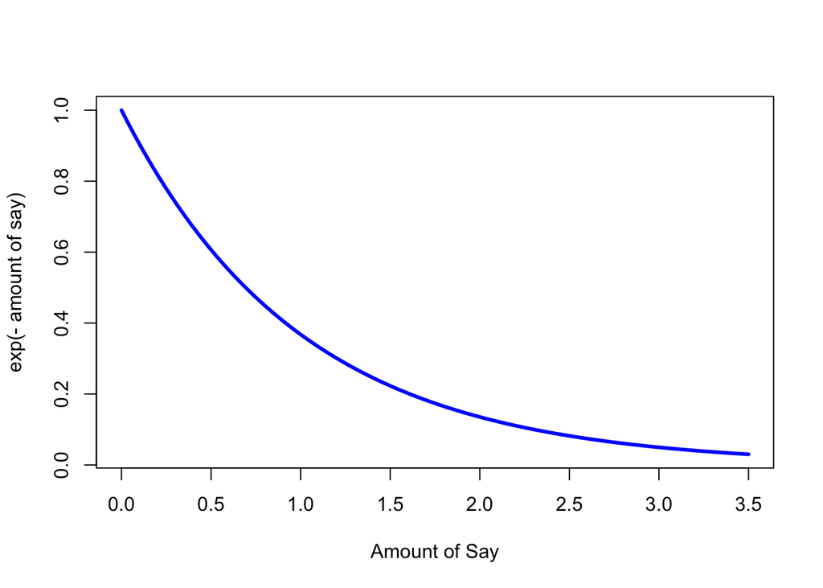

7. Create a new weight column with the increased weight for the incorrectly classified and decreased weight for the correctly classified samples.
8. **Normalise** the new sample weights so that they will add up to 1.
9. Use the **modified** sample weights to make the **second stump** in the forest, either using a **Weighted Gini Function** or the following **weighted dataset** method. Generate a new data set of the same size as the original taking the new weights into consideration. Pick a random number $x$ between **0** and **1**. Select the $j^{th}$ sample to add to the new data set if
   $$\Sigma_{i = 0}^{j} w_i < x \leq \Sigma_{i = 0}^{j + 1} w_i$$
   where $0 \leq j < N$, $w_i$ is the weight of the $i^{th}$ sample and $w_0 = 0$. This results in selecting samples with a high sample weight multiple times.
10. Give all samples of the new data set equal weights. Equal samples will be treated as a block creating a large penalty for misclassification.
11. Go back to step 1 and repeat.

## Making classifications

Add up Amounts of Say for the stumps which classified a sample as **yes** and compare to the sum of Amounts of Say for the stumps which classified it as **No**. If **yes** has the largest sum then the sample is classified as **yes**, and vice versa.